# Notebook

```python
import numpy as np
import matplotlib.pyplot as plt
import pandas as pd
import seaborn as sns
import importlib
```

```python
import Notebooks.utils.utils as utils
import Notebooks.utils.da_utils as da_utils
import src.ds_utils.dataset as dataset

import src.models.boost_ensemble.ensemble_wrapper as ensemble_wrapper
import src.models.shared.shap_analysis as shap
```

```python
sns.set_theme(style="darkgrid", palette="pastel")
plt.style.use("fivethirtyeight")
```

```python
VERBOSE = True
```

```python
utils.fix_cwd()
```

```python
importlib.reload(dataset)
ds = dataset.create_dataset(cache_path="dataset_cache/anonymize_cached_44898_default_80.csv")
```

```python
if VERBOSE:
    display(ds.full_data.sample(200))
```

|  | title | text | subject | date | fake | extracted_features | anonymized_text | num_entities | num_person_entities | num_org_entities | ... | gpe_Georgia | gpe_Egypt | gpe_Benghazi | gpe_Italy | gpe_Sweden | gpe_Philippines | gpe_Oregon | gpe_Baghdad | gpe_Orlando | gpe_Illinois |
| --- | --- | --- | --- | --- | --- | --- | --- | --- | --- | --- | --- | --- | --- | --- | --- | --- | --- | --- | --- | --- | --- |
| 15632 | UPDATE: CATHOLIC UNIVERSITY THAT STATUE REMOVE... | This is a perfect example of the effort by lib... | politics | May 27, 2015 | 1 | {'entities': [('American', 'NORP'), ('Indians'... | This is a perfect example of the effort by lib... | 28 | 5 | 8 | ... | False | False | False | False | False | False | False | False | False | False |
| 29490 | Chelsea Manning criticizes Obama, draws Trump'... | WASHINGTON (Reuters) - Former U.S. military in... | politicsNews | January 26, 2017 | 0 | {'entities': [('{RANDOM_ENTITY_GPE_0}', 'GPE')... | {RANDOM_ENTITY_GPE_0} ({RANDOM_ENTITY_ORG_1}) ... | 51 | 23 | 6 | ... | False | False | False | False | False | False | False | False | False | False |
| 22336 | WAR ON WORDS: Facebook Censorship Widens, Webs... | 21st Century Wire says The US media s neoMcCar... | US_News | December 3, 2016 | 1 | {'entities': [('{RANDOM_ENTITY_GPE_0}', 'GPE')... | 21st Century Wire says The {RANDOM_ENTITY_GPE_... | 71 | 3 | 37 | ... | False | False | False | False | False | False | False | False | False | False |
| 19487 | DEMOCRATS AREN’T AFRAID Trump Will Be A Terrib... | The brilliant, outspoken and beautiful Tomi La... | left-news | Dec 7, 2016 | 1 | {'entities': [('{RANDOM_ENTITY_PERSON_0}', 'PE... | The brilliant, outspoken and beautiful {RANDOM... | 1 | 1 | 0 | ... | False | False | False | False | False | False | False | False | False | False |
| 43007 | Palestinian President Abbas says peace closer ... | NEW YORK (Reuters) - Palestinian President Mah... | worldnews | September 20, 2017 | 0 | {'entities': [('{RANDOM_ENTITY_GPE_0}', 'GPE')... | {RANDOM_ENTITY_GPE_0} ({RANDOM_ENTITY_ORG_1}) ... | 87 | 21 | 7 | ... | False | False | False | False | False | False | False | False | False | False |
| ... | ... | ... | ... | ... | ... | ... | ... | ... | ... | ... | ... | ... | ... | ... | ... | ... | ... | ... | ... | ... | ... |
| 15714 | HAPPY MOTHER’S DAY…Your First Grader Just Rate... | Rate your mom for Mother s Day sounds like the... | politics | May 11, 2015 | 1 | {'entities': [('first', 'ORDINAL'), ('Ridgecre... | Rate your mom for {RANDOM_ENTITY_DATE_2} sound... | 16 | 1 | 1 | ... | False | False | False | False | False | False | False | False | False | False |
| 3926 | Trump Goes COMPLETELY Off The Rails Over Hill... | The right wing is still harping on the FBI s d... | News | November 5, 2016 | 1 | {'entities': [('{RANDOM_ENTITY_ORG_0}', 'ORG')... | The right wing is still harping on the {RANDOM... | 23 | 13 | 4 | ... | False | False | False | False | False | False | False | False | False | False |
| 35350 | Chile election ends era of female presidents i... | SANTIAGO (Reuters) - When Chile s President Mi... | worldnews | December 19, 2017 | 0 | {'entities': [('{RANDOM_ENTITY_ORG_0}', 'ORG')... | {RANDOM_ENTITY_ORG_0} ({RANDOM_ENTITY_ORG_1}) ... | 101 | 29 | 11 | ... | False | False | False | False | False | False | False | False | False | False |
| 3236 | Charlie Sheen Sends SHOCKING Message About Tr... | This year was a rough one and many of us can t... | News | December 29, 2016 | 1 | {'entities': [('{RANDOM_ENTITY_DATE_0}', 'DATE... | {RANDOM_ENTITY_DATE_0} was a rough one and man... | 40 | 26 | 2 | ... | False | False | False | False | False | False | False | False | False | False |
| 38093 | Venezuela's ex-prosecutor wants Maduro tried a... | CARACAS (Reuters) - Venezuela s sacked former ... | worldnews | November 16, 2017 | 0 | {'entities': [('{RANDOM_ENTITY_ORG_0}', 'ORG')... | CARACAS ({RANDOM_ENTITY_ORG_0}) - {RANDOM_ENTI... | 37 | 14 | 5 | ... | False | False | False | False | False | False | False | False | False | False |

200 rows × 289 columns

```python
if VERBOSE:
    print(len(ds.full_data.dtypes))
    with pd.option_context('display.max_rows', None):
        dtype_df = pd.DataFrame({'Column': ds.full_data.dtypes.index, 'Type': ds.full_data.dtypes.values})
        display(dtype_df)

    # display(ds.full_data.dtypes)
```

```
289
```

|  | Column | Type |
| --- | --- | --- |
| 0 | title | object |
| 1 | text | object |
| 2 | subject | object |
| 3 | date | object |
| 4 | fake | int64 |
| 5 | extracted_features | object |
| 6 | anonymized_text | object |
| 7 | num_entities | int64 |
| 8 | num_person_entities | int64 |
| 9 | num_org_entities | int64 |
| 10 | num_gpe_entities | int64 |
| 11 | num_date_entities | int64 |
| 12 | sentiment | float64 |
| 13 | num_words | int64 |
| 14 | num_sents | int64 |
| 15 | avg_word_length | float64 |
| 16 | lexical_diversity | float64 |
| 17 | readability | float64 |
| 18 | num_tokens | int64 |
| 19 | char_count | int64 |
| 20 | ner_density | float64 |
| 21 | max_dep_depth | int64 |
| 22 | avg_token_vector_norm | float64 |
| 23 | avg_sent_length | float64 |
| 24 | median_sent_length | float64 |
| 25 | std_sent_length | float64 |
| 26 | punctuation_density | float64 |
| 27 | stop_words_ratio | float64 |
| 28 | pos_ratio_PROPN | float64 |
| 29 | pos_ratio_AUX | float64 |

[output cut: 259 more lines]

```python
# print(len(ds.full_data))
```

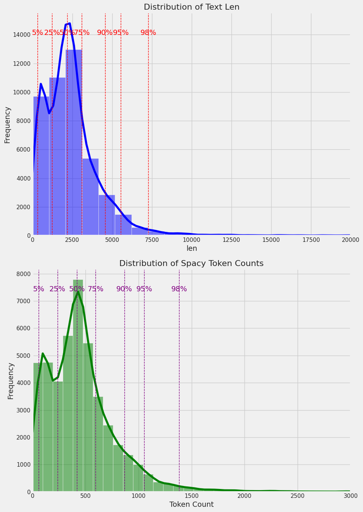

```python
importlib.reload(da_utils)
da_utils.plot_text_size_distributions(ds.full_data, text_col="text", token_counts=ds.full_data["num_tokens"])
```

[output not shown]

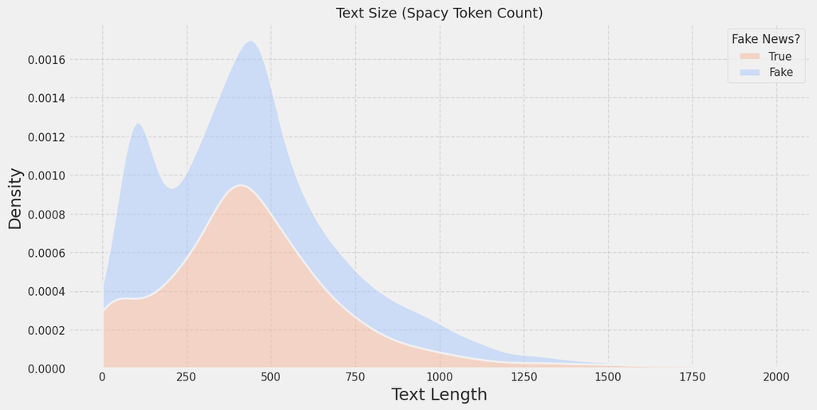

```python
importlib.reload(da_utils)
da_utils.plot_stacked_kde_text_length_vs_target(df=ds.full_data, len_column="num_tokens", target_column="fake")
```

#### 1.4 Entity Analysis

```python
# 3. Proportion of "fake" for binary columns (prefixed with person_, org_, gpe_, etc.) including count
binary_columns = ds.full_data.columns[ds.full_data.columns.str.startswith(('person_', 'org_', 'gpe_'))]
fake_proportion_binary = ds.full_data[binary_columns].mean().reset_index()

fake_proportion_binary.columns = ['binary_column', 'total_proportion']
fake_proportion_binary['total_count'] = ds.full_data[binary_columns].sum().values

d = []
for col in binary_columns:
    d.append({
        'col': col,
        'total': len(ds.full_data[ds.full_data[col] == True]),
        'fake': len(ds.full_data[(ds.full_data[col] == True) & (ds.full_data["fake"] == True)]),
        'true': len(ds.full_data[(ds.full_data[col] == True) & (ds.full_data["fake"] == False)])
    })
d = pd.DataFrame(d)
d["prop_fake"] = d["fake"] / d["total"]

d.sort_values(by="total", ascending=False)
```

|  | col | total | fake | true | prop_fake |
| --- | --- | --- | --- | --- | --- |
| 0 | person_Trump | 21541 | 11981 | 9560 | 0.556195 |
| 80 | org_Reuters | 21531 | 302 | 21229 | 0.014026 |
| 15 | person_Donald Trump s | 18051 | 8873 | 9178 | 0.491552 |
| 10 | person_@realDonaldTrump | 16995 | 7961 | 9034 | 0.468432 |
| 160 | gpe_U.S. | 16027 | 4671 | 11356 | 0.291446 |
| ... | ... | ... | ... | ... | ... |
| 61 | person_Reilly | 217 | 206 | 11 | 0.949309 |
| 53 | person_Gorsuch | 217 | 79 | 138 | 0.364055 |
| 226 | gpe_Flint | 201 | 145 | 56 | 0.721393 |
| 50 | person_Mugabe | 192 | 4 | 188 | 0.020833 |
| 140 | org_SPD | 179 | 6 | 173 | 0.033520 |

240 rows × 5 columns

```python
total_samples = len(ds.full_data)
overall_fake_proportion = ds.full_data['fake'].mean()

d['total_normalized'] = d['total'] / total_samples
d['prop_fake_normalized'] = d['prop_fake'] - overall_fake_proportion

# Create importance score (you can adjust the weights if needed)
d['importance_score'] = 0.5 * d['total_normalized'] + 0.5 * abs(d['prop_fake_normalized'])

# Sort by importance score
d_sorted = d.sort_values('importance_score', ascending=False)
```

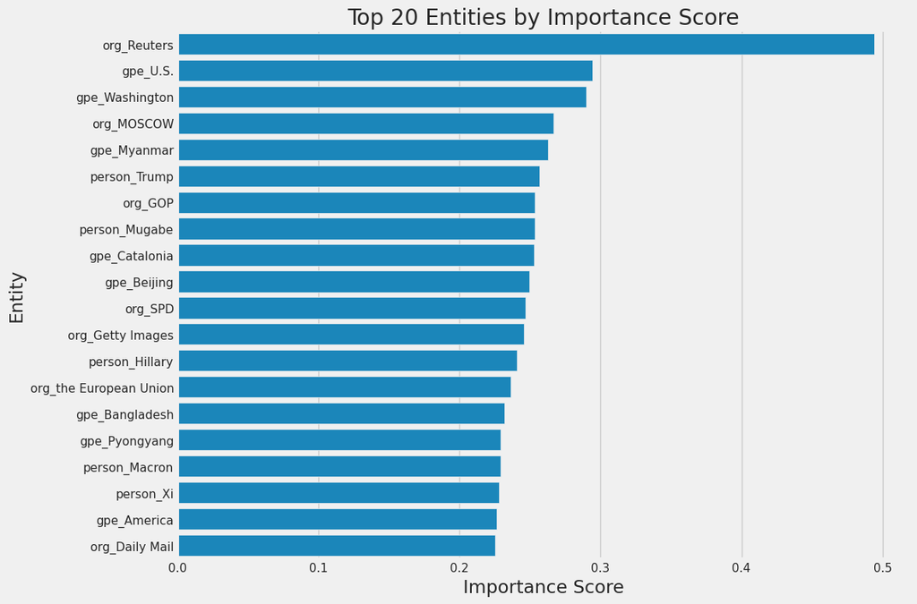

```python
plt.figure(figsize=(12, 8))
sns.barplot(x='importance_score', y='col', data=d_sorted.head(20))
plt.title('Top 20 Entities by Importance Score')
plt.xlabel('Importance Score')
plt.ylabel('Entity')
plt.tight_layout()
plt.show()
```

[output not shown]

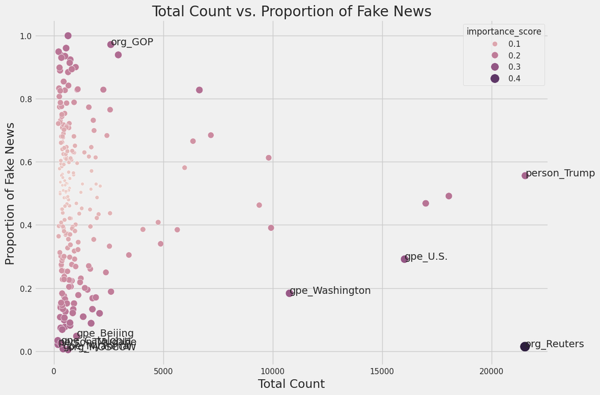

```python
plt.figure(figsize=(12, 8))
sns.scatterplot(x='total', y='prop_fake', data=d, hue='importance_score', size='importance_score', sizes=(20, 200))
plt.title('Total Count vs. Proportion of Fake News')
plt.xlabel('Total Count')
plt.ylabel('Proportion of Fake News')
for i, row in d_sorted.head(10).iterrows():
    plt.annotate(row['col'], (row['total'], row['prop_fake']))
plt.tight_layout()
plt.show()
```

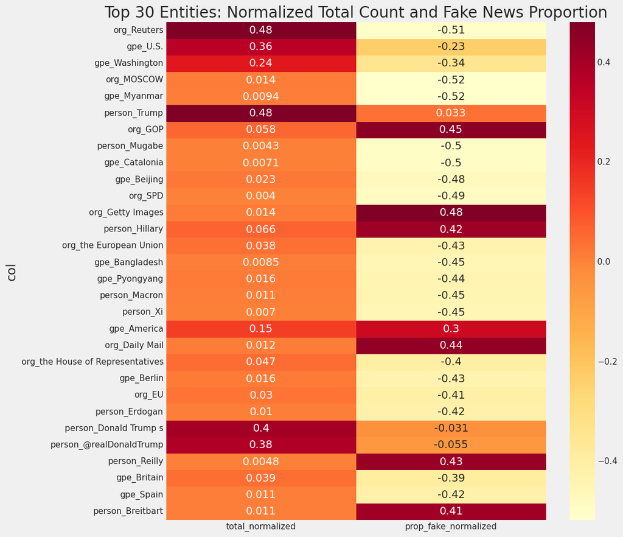

```python
top_30 = d_sorted.head(30).set_index('col')
plt.figure(figsize=(12, 10))
sns.heatmap(top_30[['total_normalized', 'prop_fake_normalized']], annot=True, cmap='YlOrRd')
plt.title('Top 30 Entities: Normalized Total Count and Fake News Proportion')
plt.tight_layout()
plt.show()
```

```python
# entity_type_summary = d.groupby('entity_type').agg({
#     'total': 'sum',
#     'prop_fake': 'mean',
#     'importance_score': 'mean'
# }).sort_values('importance_score', ascending=False)
#
# entity_type_summary
```

```python
correlation_matrix = d[['total', 'prop_fake', 'importance_score']].corr()
correlation_matrix
```

|  | total | prop_fake | importance_score |
| --- | --- | --- | --- |
| total | 1.000000 | -0.063512 | 0.388932 |
| prop_fake | -0.063512 | 1.000000 | -0.277533 |
| importance_score | 0.388932 | -0.277533 | 1.000000 |

#### 1.4.1 PCA

```python
numeric_feats = ds.full_data.select_dtypes(include=[np.number])
# float_columns = df.select_dtypes(include=['float'])

numeric_feats
```

|  | fake | num_entities | num_person_entities | num_org_entities | num_gpe_entities | num_date_entities | sentiment | num_words | num_sents | avg_word_length | ... | pos_ratio_PRON | pos_ratio_SPACE | pos_ratio_X | pos_ratio_SCONJ | pos_ratio_DET | pos_ratio_PUNCT | pos_ratio_CCONJ | verb_tense_ratio_past | verb_tense_ratio_present | verb_tense_ratio_future |
| --- | --- | --- | --- | --- | --- | --- | --- | --- | --- | --- | --- | --- | --- | --- | --- | --- | --- | --- | --- | --- | --- |
| 22216 | 1 | 13 | 6 | 4 | 3 | 0 | 0.08333 | 187 | 7 | 4.58824 | ... | 0.01070 | 0.02674 | 0.00000 | 0.01070 | 0.12299 | 0.05348 | 0.04278 | 0.45455 | 0 | 0 |
| 27917 | 0 | 114 | 49 | 28 | 18 | 10 | 0.08660 | 904 | 29 | 4.47898 | ... | 0.04978 | 0.00221 | 0.00000 | 0.00664 | 0.08407 | 0.11394 | 0.02102 | 0.60759 | 0 | 0 |
| 25007 | 0 | 26 | 5 | 4 | 6 | 4 | -0.00504 | 359 | 14 | 4.30084 | ... | 0.06128 | 0.01114 | 0.00000 | 0.01114 | 0.08635 | 0.12813 | 0.01393 | 0.64706 | 0 | 0 |
| 1377 | 1 | 24 | 8 | 1 | 8 | 3 | -0.01116 | 230 | 12 | 4.61739 | ... | 0.08696 | 0.06957 | 0.00000 | 0.01739 | 0.07391 | 0.10870 | 0.01304 | 0.73077 | 0 | 0 |
| 32476 | 0 | 75 | 10 | 15 | 19 | 9 | 0.03935 | 606 | 23 | 4.30363 | ... | 0.06601 | 0.00165 | 0.00000 | 0.01320 | 0.08581 | 0.10561 | 0.01980 | 0.53846 | 0 | 0 |
| ... | ... | ... | ... | ... | ... | ... | ... | ... | ... | ... | ... | ... | ... | ... | ... | ... | ... | ... | ... | ... | ... |
| 11284 | 1 | 0 | 0 | 0 | 0 | 0 | 0.00000 | 1 | 1 | 1.00000 | ... | 0.00000 | 1.00000 | 0.00000 | 0.00000 | 0.00000 | 0.00000 | 0.00000 | 0.00000 | 0 | 0 |
| 44732 | 0 | 121 | 17 | 20 | 34 | 22 | 0.06335 | 807 | 24 | 4.50310 | ... | 0.03346 | 0.01735 | 0.00000 | 0.01611 | 0.06568 | 0.08674 | 0.02726 | 0.52830 | 0 | 0 |
| 38158 | 0 | 6 | 1 | 1 | 1 | 2 | -0.10606 | 89 | 5 | 4.02247 | ... | 0.11236 | 0.04494 | 0.00000 | 0.01124 | 0.06742 | 0.13483 | 0.02247 | 0.28571 | 0 | 0 |
| 860 | 1 | 111 | 26 | 21 | 1 | 25 | -0.03391 | 1092 | 48 | 3.83700 | ... | 0.06868 | 0.04579 | 0.00183 | 0.02198 | 0.05586 | 0.14011 | 0.01282 | 0.28986 | 0 | 0 |
| 15795 | 1 | 36 | 10 | 13 | 4 | 3 | 0.03011 | 290 | 10 | 4.21724 | ... | 0.03103 | 0.01034 | 0.00000 | 0.00690 | 0.10000 | 0.10345 | 0.01379 | 0.57143 | 0 | 0 |

44898 rows × 43 columns

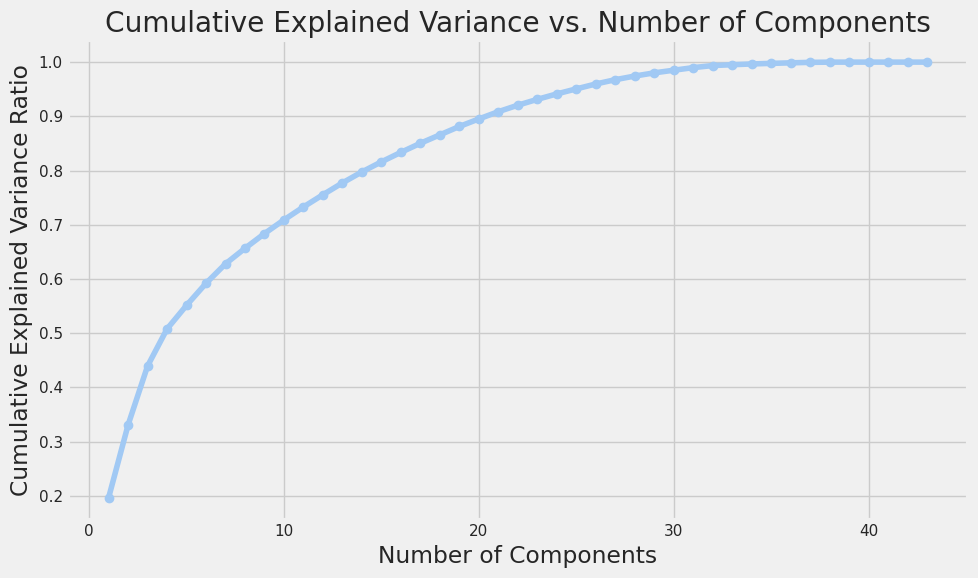

```
Number of components needed to explain 95% of the variance: 25
```

```python
from sklearn.preprocessing import StandardScaler
from sklearn.decomposition import PCA

# Drop the 'fake' column if it exists
if 'fake' in numeric_feats.columns:
    df = numeric_feats.drop('fake', axis=1)

# Prepare the data for PCA
X = numeric_feats.select_dtypes(include=[np.number])
X_scaled = StandardScaler().fit_transform(X)

# Perform PCA
pca = PCA()
pca.fit(X_scaled)

# Calculate cumulative explained variance ratio
cumulative_variance_ratio = np.cumsum(pca.explained_variance_ratio_)

# Plot cumulative explained variance
plt.figure(figsize=(10, 6))
plt.plot(range(1, len(cumulative_variance_ratio) + 1), cumulative_variance_ratio, 'bo-')
plt.xlabel('Number of Components')
plt.ylabel('Cumulative Explained Variance Ratio')
plt.title('Cumulative Explained Variance vs. Number of Components')
plt.grid(True)
plt.tight_layout()
plt.show()

# Print the number of components needed to explain 95% of the variance
n_components_95 = np.argmax(cumulative_variance_ratio >= 0.95) + 1
print(f"Number of components needed to explain 95% of the variance: {n_components_95}")
```

```python
from sklearn.manifold import TSNE

# T-SNE
input_df = numeric_feats.copy()

# Drop the 'fake' column if it exists
if 'fake' in input_df.columns:
    input_df = input_df.drop('fake', axis=1)

# Prepare the data for t-SNE
features_for_tsne = input_df.select_dtypes(include=[np.number])  # Select only numeric columns
scaled_features = StandardScaler().fit_transform(features_for_tsne)

# Perform t-SNE
tsne = TSNE(n_components=2, random_state=42)
tsne_results = tsne.fit_transform(scaled_features)
```

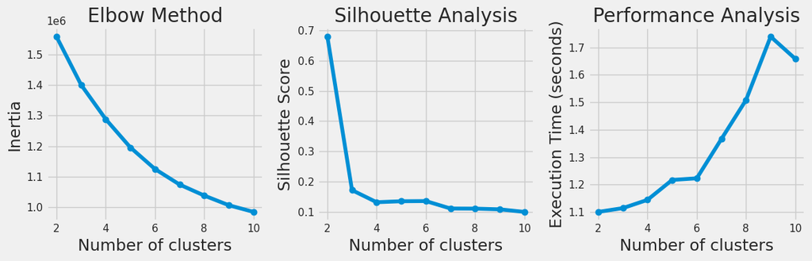

```python
import pandas as pd
import numpy as np
from sklearn.preprocessing import StandardScaler
from sklearn.cluster import KMeans
from sklearn.metrics import silhouette_score
import matplotlib.pyplot as plt
import time

data = numeric_feats.copy()
# Remove the 'fake' column
features = data.drop('fake', axis=1)

# Standardize the features
scaler = StandardScaler()
scaled_features = scaler.fit_transform(features)

# Function to perform K-means clustering
def perform_kmeans(data, max_clusters=10):
    inertias = []
    silhouette_scores = []
    times = []

    for k in range(2, max_clusters + 1):
        start_time = time.time()
        kmeans = KMeans(n_clusters=k, n_init=10, random_state=42)
        kmeans.fit(data)
        end_time = time.time()

        inertias.append(kmeans.inertia_)
        silhouette_scores.append(silhouette_score(data, kmeans.labels_))
        times.append(end_time - start_time)

    return inertias, silhouette_scores, times

# Perform K-means for different numbers of clusters
inertias, silhouette_scores, times = perform_kmeans(scaled_features)

# Plot the elbow curve
plt.figure(figsize=(12, 4))
plt.subplot(131)
plt.plot(range(2, len(inertias) + 2), inertias, marker='o')
plt.xlabel('Number of clusters')
plt.ylabel('Inertia')
plt.title('Elbow Method')

# Plot the silhouette scores
plt.subplot(132)
plt.plot(range(2, len(silhouette_scores) + 2), silhouette_scores, marker='o')
plt.xlabel('Number of clusters')
plt.ylabel('Silhouette Score')
plt.title('Silhouette Analysis')

# Plot the execution times
plt.subplot(133)
plt.plot(range(2, len(times) + 2), times, marker='o')
plt.xlabel('Number of clusters')
plt.ylabel('Execution Time (seconds)')
plt.title('Performance Analysis')

plt.tight_layout()
plt.show()
```

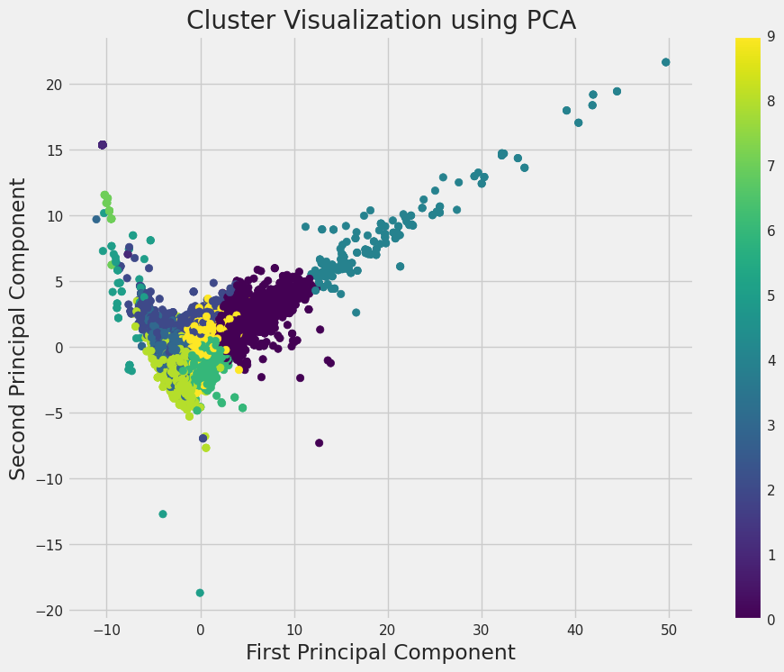

```python
# Determine the optimal number of clusters (you may need to adjust this based on the plots)
optimal_clusters = 10  # This is an example, adjust based on your analysis

# Perform final clustering with the optimal number of clusters
final_kmeans = KMeans(n_clusters=optimal_clusters, n_init=10, random_state=42)
cluster_labels = final_kmeans.fit_predict(scaled_features)

# Add cluster labels to the original dataset
data['Cluster'] = cluster_labels

# # Print summary statistics for each cluster
# for cluster in range(optimal_clusters):
#     print(f"\nCluster {cluster} Statistics:")
#     print(data[data['Cluster'] == cluster].describe())

# Visualize the clusters using the first two principal components (optional)
from sklearn.decomposition import PCA

pca = PCA(n_components=2)
pca_result = pca.fit_transform(scaled_features)

plt.figure(figsize=(10, 8))
scatter = plt.scatter(pca_result[:, 0], pca_result[:, 1], c=cluster_labels, cmap='viridis')
plt.colorbar(scatter)
plt.xlabel('First Principal Component')
plt.ylabel('Second Principal Component')
plt.title('Cluster Visualization using PCA')
plt.show()
```

[figure not shown]

```
t-SNE Results Shape: (44898, 2)
t-SNE Range - X: -94.89072 to 95.122025
t-SNE Range - Y: -95.44623 to 91.66013
```

```python
# Create a scatter plot of the t-SNE results
plt.figure(figsize=(10, 8))
scatter = plt.scatter(tsne_results[:, 0],
                      tsne_results[:, 1],
                      alpha=0.75,
                      s=1,
                      c=cluster_labels,
                      # c=features_for_tsne['sentiment'],

                      cmap='viridis')
plt.colorbar(scatter, label='Fake News')
plt.title('t-SNE Visualization of Clusters')
plt.xlabel('t-SNE feature 1')
plt.ylabel('t-SNE feature 2')
plt.tight_layout()
plt.show()

# Print some statistics about the t-SNE results
print("t-SNE Results Shape:", tsne_results.shape)
print("t-SNE Range - X:", tsne_results[:, 0].min(), "to", tsne_results[:, 0].max())
print("t-SNE Range - Y:", tsne_results[:, 1].min(), "to", tsne_results[:, 1].max())

# Optionally, you can save the t-SNE results back to the dataframe
input_df['tsne_1'] = tsne_results[:, 0]
input_df['tsne_2'] = tsne_results[:, 1]
```

```python
USE FASTTEXT EMBEDDINGS (unsupervised) for clustering
    SEE:

    https://chatgpt.com/c/8bbeec1a-00e9-4840-b874-8cb225ca2fbc

    !!
```

```python
OR BETTER USE BERT EMBEDDINGS
```

```python
BERT EMBEDDINGS:

T-SNE and CLUSTER
```

[output not shown]

[output cut: 18 more lines]

```python
from contextlib import nullcontext
import torch
from transformers import AlbertTokenizer, AlbertModel
from sklearn.manifold import TSNE
from sklearn.cluster import KMeans
import numpy as np
import pandas as pd
import matplotlib.pyplot as plt
from tqdm import tqdm
from torch.utils.data import DataLoader, Dataset
from transformers import AutoTokenizer, AutoModel
from torch.cuda.amp import autocast
import os
os.environ["TOKENIZERS_PARALLELISM"] = "false"


# tokenizer = AlbertTokenizer.from_pretrained(model_name)
# model = AlbertModel.from_pretrained(model_name)


class TextDataset(Dataset):
    def __init__(self, texts, tokenizer, max_length):
        self.texts = texts
        self.tokenizer = tokenizer
        self.max_length = max_length

    def __len__(self):
        return len(self.texts)

    def __getitem__(self, idx):
        text = self.texts[idx]
        inputs = self.tokenizer(text, padding="max_length", truncation="longest_first",
                                max_length=self.max_length, return_tensors="pt")
        return {k: v.squeeze(0) for k, v in inputs.items()}

def get_embeddings(texts, model, tokenizer=None, batch_size=32, max_length=512, use_gpu=True, model_type='auto'):
    device = torch.device('cuda' if use_gpu and torch.cuda.is_available() else 'cpu')
    model = model.to(device)

    if model_type == 'auto':
        model = model.half() if use_gpu else model
        model.eval()

        dataset = TextDataset(texts, tokenizer, max_length)
        dataloader = DataLoader(dataset, batch_size=batch_size, shuffle=False, num_workers=0 if use_gpu else 4)

        embeddings = []

        with torch.no_grad(), (autocast() if use_gpu else nullcontext()):
            for batch in tqdm(dataloader, desc="Generating embeddings"):
                batch = {k: v.to(device) for k, v in batch.items()}
                outputs = model(**batch)
                batch_embeddings = outputs.last_hidden_state[:, 0, :]
                embeddings.append(batch_embeddings.cpu())

        return torch.cat(embeddings).numpy()

    elif model_type == 'sentence_transformer':
        if isinstance(texts, pd.Series):
            texts = texts.tolist()



        model.eval()
        if use_gpu:
            model = model.half()  # Use half-precision if on GPU

        embeddings = []

        with torch.no_grad(), (torch.cuda.amp.autocast() if use_gpu else nullcontext()):
            for i in tqdm(range(0, len(texts), batch_size), desc="Generating embeddings"):
                batch = texts[i:i+batch_size]
                batch_embeddings = model.encode(batch, device=device, convert_to_tensor=True)
                embeddings.append(batch_embeddings.cpu())

        return torch.cat(embeddings).numpy()

    else:
        raise ValueError("Invalid model_type. Choose 'auto' or 'sentence_transformer'.")



# def get_embeddings(texts, batch_size=32):
#     device = torch.device('cuda' if torch.cuda.is_available() else 'cpu')
#     model.to(device)
#     model.eval()
#
#     embeddings = []
#
#     for i in tqdm(range(0, len(texts), batch_size), desc="Generating embeddings"):
#         batch_texts = texts[i:i+batch_size]
#
#         # Truncate and tokenize
#         truncated_texts = [truncate_from_middle(text, 512) for text in batch_texts]
#         inputs = tokenizer(truncated_texts, return_tensors="pt", padding=True, truncation=True, max_length=512)
#
#         inputs = {k: v.to(device) for k, v in inputs.items()}
#
#         with torch.no_grad():
#             outputs = model(**inputs)
#
#         # Use the [CLS] token embedding as the sentence embedding
#         batch_embeddings = outputs.last_hidden_state[:, 0, :].cpu().numpy()
#         embeddings.extend(batch_embeddings)
#
#     return np.array(embeddings)

def cluster_and_visualize(embeddings, n_clusters=5):
    # Perform K-means clustering
    kmeans = KMeans(n_clusters=n_clusters, random_state=42)
    cluster_labels = kmeans.fit_predict(embeddings)

    # Perform t-SNE for visualization
    tsne = TSNE(n_components=2, random_state=42)
    reduced_embeddings = tsne.fit_transform(embeddings)

    # Visualize
    plt.figure(figsize=(10, 8))
    scatter = plt.scatter(reduced_embeddings[:, 0], reduced_embeddings[:, 1],
                          c=cluster_labels, alpha=0.6, cmap='viridis')
    plt.colorbar(scatter)
    plt.title('t-SNE visualization of text embeddings')
    plt.xlabel('t-SNE feature 1')
    plt.ylabel('t-SNE feature 2')
    plt.show()

    return cluster_labels
```

```python
from sentence_transformers import SentenceTransformer

model_name = "huawei-noah/TinyBERT_General_4L_312D"
tokenizer = AutoTokenizer.from_pretrained(model_name, use_fast=True)
model = AutoModel.from_pretrained(model_name)
# Usage for SentenceTransformer
model_st = SentenceTransformer('all-MiniLM-L6-v2')
```

```python
embedding_df = ds.full_data.copy()

embeddings_tinybert = get_embeddings(embedding_df["text"], model,  tokenizer, batch_size=256, use_gpu=True, model_type='auto')
```

[output not shown]

```python
embeddings_st = get_embeddings(embedding_df["text"], model_st, batch_size=256, use_gpu=True, model_type='sentence_transformer')
```

```python
import gc
gc.collect()
torch.cuda.empty_cache()
```

```python
embeddings_st
```

```
array([[-0.04292417,  0.04017529,  0.00822352, ...,  0.00830901,
         0.04013212, -0.05353491],
       [-0.0300238 , -0.05997578,  0.09334268, ..., -0.08667795,
        -0.02973704,  0.06296595],
       [ 0.0077344 ,  0.01727735,  0.01518998, ..., -0.06386147,
        -0.015207  , -0.02204838],
       ...,
       [-0.00774679, -0.00621239,  0.02480308, ..., -0.05097079,
         0.00514519,  0.00038478],
       [ 0.06024081,  0.06292548,  0.00465201, ..., -0.00634774,
         0.04170959,  0.02873757],
       [ 0.00446899, -0.08325394, -0.00282552, ..., -0.16707481,
         0.09308673, -0.04893658]], dtype=float32)
```

```python
# Copyimport numpy as np
import matplotlib.pyplot as plt
from sklearn.manifold import TSNE
from hdbscan import HDBSCAN
from sklearn.metrics import silhouette_score
```

```python
def cluster_and_visualize(embeddings, min_cluster_size=500, min_samples=5):
    # HDBSCAN Clustering
    clusterer = HDBSCAN(min_cluster_size=min_cluster_size, min_samples=min_samples)
    cluster_labels = clusterer.fit_predict(embeddings)

    # Calculate silhouette score
    silhouette_avg = silhouette_score(embeddings, cluster_labels)
    print(f"Silhouette Score: {silhouette_avg}")

    # t-SNE for dimensionality reduction
    tsne = TSNE(n_components=2, random_state=42)
    embeddings_2d = tsne.fit_transform(embeddings)

    # Plotting
    plt.figure(figsize=(10, 8))
    scatter = plt.scatter(embeddings_2d[:, 0], embeddings_2d[:, 1], c=cluster_labels, cmap='viridis')
    plt.colorbar(scatter)
    plt.title(f'HDBSCAN Clustering of Text Embeddings (Silhouette Score: {silhouette_avg:.2f})')
    plt.xlabel('t-SNE feature 0')
    plt.ylabel('t-SNE feature 1')
    plt.show()

    return cluster_labels

cluster_labels = cluster_and_visualize(embeddings_st)
```

[output not shown]

```python
Pipeline options:

1. Use spacy to summarize?
```

#### 1.5 Temporal Analysis

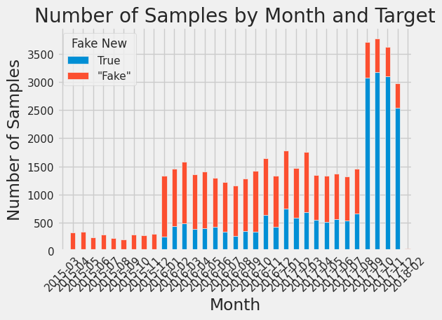

```python
importlib.reload(da_utils)
da_utils.sample_plot_by_time(ds.full_data)
```

[output not shown]

#### 3.0 Heuristics Based Model

Our goal is not to maximize performance but rather to {find issues in the dataset}:

- Is the model overfitting on some entitites? e.g. Reuters might almost never report "fake" news, but we can't guarantee that won't change in the future. Also, a model that would rely on specific keywords would be trivial to game.

##### 3.1 Feature Selection

```python
THRESHOLD = 0.25
dropped_cols = d_sorted[d_sorted['prop_fake_normalized'].abs() > THRESHOLD]
print(f"Dropping total columns: {len(dropped_cols)}")
drop_cols = dropped_cols["col"]
dropped_cols.sort_values(by='total', ascending=False)
```

```
Dropping total columns: 90
```

|  | col | total | fake | true | prop_fake | total_normalized | prop_fake_normalized | importance_score |
| --- | --- | --- | --- | --- | --- | --- | --- | --- |
| 80 | org_Reuters | 21531 | 302 | 21229 | 0.014026 | 0.479554 | -0.508959 | 0.494256 |
| 162 | gpe_Washington | 10768 | 1973 | 8795 | 0.183228 | 0.239833 | -0.339757 | 0.289795 |
| 164 | gpe_America | 6650 | 5505 | 1145 | 0.827820 | 0.148114 | 0.304834 | 0.226474 |
| 3 | person_Hillary | 2943 | 2764 | 179 | 0.939178 | 0.065549 | 0.416192 | 0.240870 |
| 165 | gpe_China | 2611 | 492 | 2119 | 0.188434 | 0.058154 | -0.334552 | 0.196353 |
| ... | ... | ... | ... | ... | ... | ... | ... | ... |
| 154 | org_Confederate | 249 | 201 | 48 | 0.807229 | 0.005546 | 0.284243 | 0.144895 |
| 158 | org_IRS | 234 | 195 | 39 | 0.833333 | 0.005212 | 0.310348 | 0.157780 |
| 61 | person_Reilly | 217 | 206 | 11 | 0.949309 | 0.004833 | 0.426323 | 0.215578 |
| 50 | person_Mugabe | 192 | 4 | 188 | 0.020833 | 0.004276 | -0.502152 | 0.253214 |
| 140 | org_SPD | 179 | 6 | 173 | 0.033520 | 0.003987 | -0.489466 | 0.246726 |

90 rows × 8 columns

```python
from sklearn.model_selection import train_test_split

numeric_and_binary = ds.full_data.select_dtypes(include=[np.number, 'bool'])
X = numeric_and_binary.drop('fake', axis=1)  # All columns except 'fake'
y = numeric_and_binary['fake']  # Target column

# Split the data
X_train, X_test, y_train, y_test = train_test_split(X, y, test_size=0.2, random_state=42)

X_2 = X.drop(columns=drop_cols)
X_train_no_r, X_test_no_r, y_train_no_r, y_test_no_r = train_test_split(X_2, y, test_size=0.2, random_state=42)
```

```python
print(len(X.columns))
print(len(X_train_no_r.columns))
```

```
282
192
```

```python
importlib.reload(ensemble_wrapper)
tuning_results, tuning_params = ensemble_wrapper.tune_lgbm_model(
    X_train=X_train,
    y_train=y_train,
    X_val=X_test,
    y_val=y_test,
    n_trials=3, verbose=2)

tuning_results_no_r, tuning_params_no_r = ensemble_wrapper.tune_lgbm_model(
    X_train=X_train_no_r,
    y_train=y_train_no_r,
    X_val=X_test_no_r,
    y_val=y_test_no_r,
    n_trials=3, verbose=2)
```

```python
tuning_results
```

|  | number | value | datetime_start | datetime_complete | duration | params_bagging_fraction | params_bagging_freq | params_feature_fraction | params_lambda_l1 | params_lambda_l2 | params_learning_rate | params_min_child_samples | params_num_leaves | state |
| --- | --- | --- | --- | --- | --- | --- | --- | --- | --- | --- | --- | --- | --- | --- |
| 1 | 1 | 0.999845 | 2024-08-13 18:51:21.834861 | 2024-08-13 18:51:25.769572 | 0 days 00:00:03.934711 | 0.972919 | 6 | 0.118526 | 4.329370e-07 | 4.473429e-07 | 0.133112 | 25 | 159 | COMPLETE |
| 2 | 2 | 0.999713 | 2024-08-13 18:51:25.772550 | 2024-08-13 18:51:29.750344 | 0 days 00:00:03.977794 | 0.362106 | 5 | 0.488751 | 4.258943e-06 | 1.982698e-05 | 0.037521 | 18 | 88 | COMPLETE |
| 0 | 0 | 0.999662 | 2024-08-13 18:51:19.022850 | 2024-08-13 18:51:21.831381 | 0 days 00:00:02.808531 | 0.638793 | 2 | 0.758795 | 3.332365e-08 | 6.245760e-01 | 0.711448 | 19 | 105 | COMPLETE |

```python
best_params = {'num_leaves': 105,
  'learning_rate': 0.711447600934342,
  'feature_fraction': 0.7587945476302645,
  'bagging_fraction': 0.6387926357773329,
  'bagging_freq': 2,
  'min_child_samples': 19,
  'lambda_l1': 3.3323645788192616e-08,
  'lambda_l2': 0.6245760287469893,
  'value': 0.9996621866873512}

# final_model, _eval_results = ensemble_wrapper.train_lgbm_model(X_train, y_train, X_test, y_test, best_params)
final_model_no_r, _eval_results_no_r = ensemble_wrapper.train_lgbm_model(X_train_no_r, y_train_no_r, X_test_no_r, y_test_no_r, best_params)
```

```
Training until validation scores don't improve for 50 rounds
[100]	valid_0's auc: 0.9976
[200]	valid_0's auc: 0.997842
[300]	valid_0's auc: 0.997924
[400]	valid_0's auc: 0.99803
Early stopping, best iteration is:
[402]	valid_0's auc: 0.998034
Training LightGBM model took 7.13 seconds
```

```python
test_metrics = ensemble_wrapper.evaluate_model(final_model_no_r, X_test_no_r, y_test_no_r)
print("Test Metrics:")
test_metrics
```

```
Test Metrics:
```

```
{'accuracy': 0.9816258351893096,
 'precision': 0.9840255591054313,
 'recall': 0.9808917197452229,
 'f1': 0.9824561403508771,
 'auc': 0.998033632164362,
 'log_loss': 0.08163107432287664}
```

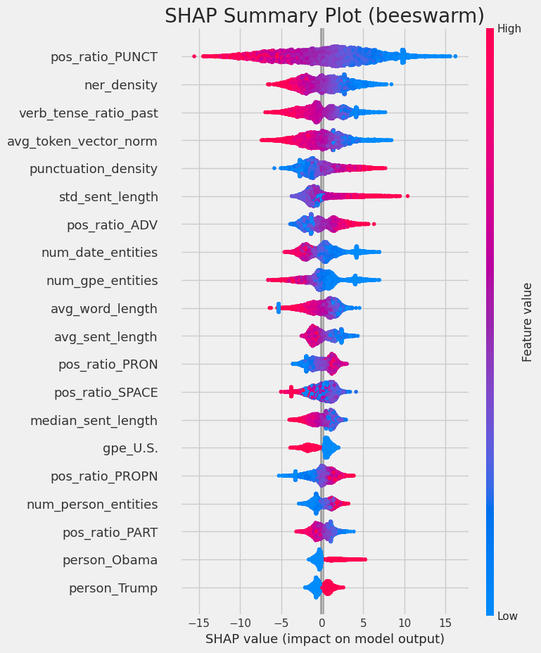

```python
importlib.reload(shap)
explainer, shap_values = shap.plot_shap_summary(final_model_no_r, X_test_no_r, plot_type="beeswarm")
```

```python
if VERBOSE:
    importlib.reload(ensemble_wrapper)
    combined_imp = ensemble_wrapper.get_combined_feature_importance(final_model_no_r, X_train_no_r)
    combined_imp_test = ensemble_wrapper.get_combined_feature_importance(final_model_no_r, X_test_no_r)

    # feature_imp_df = ensemble_wrapper.get_feature_importances(final_model_no_r, X_test_no_r.columns)
    # display(feature_imp_df.sort_values(by=["importance_percentage"], ascending=False).head(25))
```

```python
if VERBOSE:
    display(combined_imp.sort_values(by=["mean_abs_shap"], ascending=False).head(25))
```

|  | feature | importance | importance_percentage | mean_abs_shap | shap_importance_percentage |
| --- | --- | --- | --- | --- | --- |
| 5 | pos_ratio_PUNCT | 1259 | 3.035344 | 4.402535 | 10.296663 |
| 9 | ner_density | 1204 | 2.902744 | 2.211655 | 5.172626 |
| 2 | verb_tense_ratio_past | 1383 | 3.334298 | 2.019577 | 4.723392 |
| 3 | avg_token_vector_norm | 1364 | 3.288490 | 1.865964 | 4.364123 |
| 16 | punctuation_density | 1123 | 2.707459 | 1.830244 | 4.280579 |
| 1 | std_sent_length | 1397 | 3.368051 | 1.689886 | 3.952311 |
| 8 | pos_ratio_ADV | 1246 | 3.004002 | 1.572365 | 3.677453 |
| 30 | num_date_entities | 746 | 1.798544 | 1.551266 | 3.628105 |
| 25 | num_gpe_entities | 884 | 2.131250 | 1.450836 | 3.393219 |
| 13 | avg_word_length | 1150 | 2.772554 | 1.380218 | 3.228058 |
| 23 | avg_sent_length | 983 | 2.369931 | 1.142517 | 2.672123 |
| 15 | pos_ratio_PRON | 1130 | 2.724336 | 1.127723 | 2.637522 |
| 4 | pos_ratio_SPACE | 1266 | 3.052220 | 1.093518 | 2.557523 |
| 26 | median_sent_length | 881 | 2.124018 | 1.081556 | 2.529546 |
| 22 | pos_ratio_PROPN | 1008 | 2.430204 | 1.071308 | 2.505578 |
| 41 | gpe_U.S. | 73 | 0.175997 | 1.050933 | 2.457926 |
| 28 | num_person_entities | 835 | 2.013115 | 0.928912 | 2.172543 |
| 6 | pos_ratio_PART | 1252 | 3.018468 | 0.849034 | 1.985723 |
| 40 | person_Obama | 86 | 0.207339 | 0.798815 | 1.868271 |
| 43 | person_Trump | 54 | 0.130189 | 0.781697 | 1.828234 |
| 29 | num_org_entities | 802 | 1.933555 | 0.725261 | 1.696243 |
| 32 | num_words | 585 | 1.410386 | 0.652742 | 1.526636 |
| 24 | pos_ratio_NUM | 896 | 2.160181 | 0.648339 | 1.516337 |
| 56 | person_@realDonaldTrump | 41 | 0.098848 | 0.598985 | 1.400909 |
| 12 | pos_ratio_SCONJ | 1173 | 2.828005 | 0.575131 | 1.345118 |

```python
# Plot SHAP dependence for a specific feature
shap.plot_shap_dependence(final_model_no_r, X_test_no_r, "pos_ratio_PUNCT")
```

[output not shown]

#### 3.3 Feature Analysis

##### 3.3.1 pos_ratio_PUNCT

'pos_ratio_PUNCT' is the ratio of punctuation tokens to the total number of tokens (based on Spacy 'PUNCT' tag). This feature indicates the relative frequency of punctuation in the text, which can be informative about writing style, formality, or the type of content.

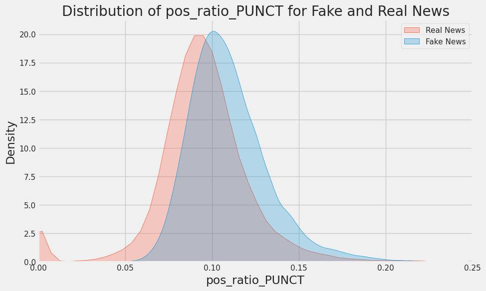

```python
da_utils.render_rel_kde_plot(ds.full_data, 'pos_ratio_PUNCT')
```

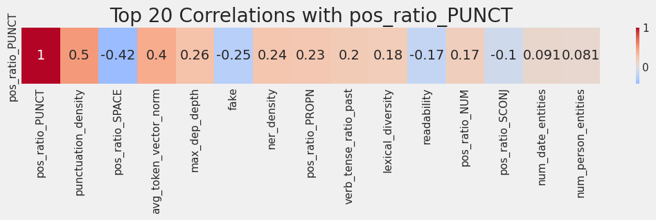

```python
importlib.reload(da_utils)
da_utils.corr_strip(ds.full_data, 'pos_ratio_PUNCT')
```

##### 3.3.2 ner_DENSITY

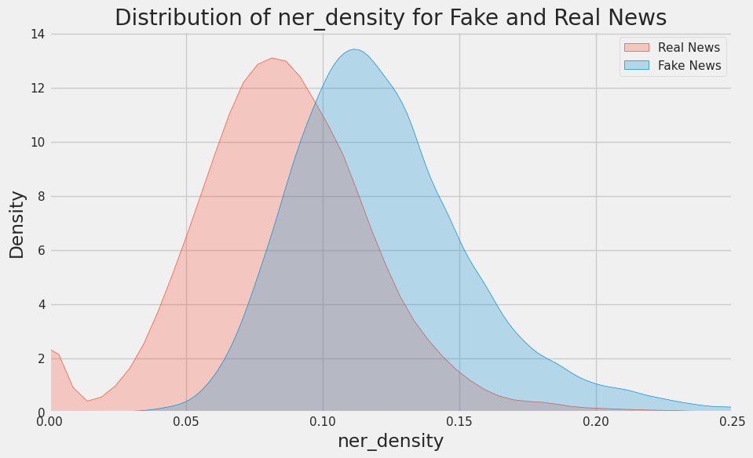

```python
da_utils.render_rel_kde_plot(ds.full_data, 'ner_density')
```

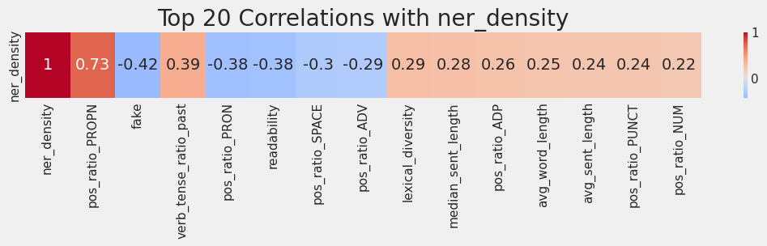

```python
importlib.reload(da_utils)
da_utils.corr_strip(ds.full_data, 'ner_density')
```

##### 3.3.3 verb_tense_ratio_past

The proportion of verbs in the text that are in the past tense. A higher value indicates more historical or narrative content.

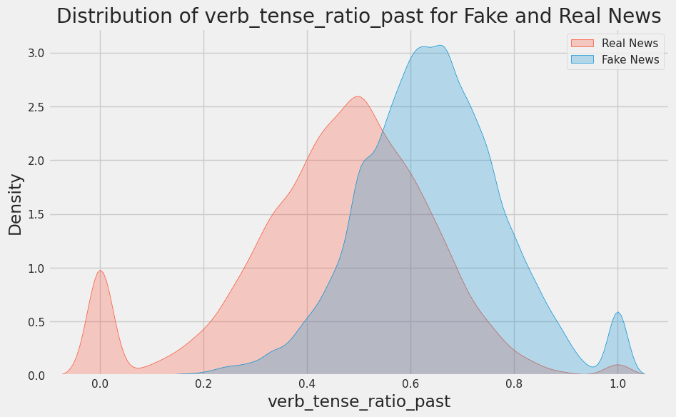

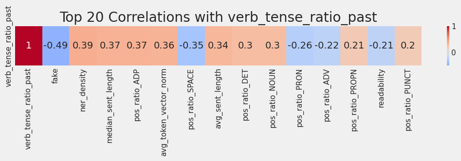

```python
da_utils.render_rel_kde_plot(ds.full_data, 'verb_tense_ratio_past', x_lim=(-0.1,1.1))
da_utils.corr_strip(ds.full_data, 'verb_tense_ratio_past')
```

##### 3.3.4 avg_token_vector_norm

The average magnitude of word vectors in the text. Higher values suggest more semantically rich or specific vocabulary.

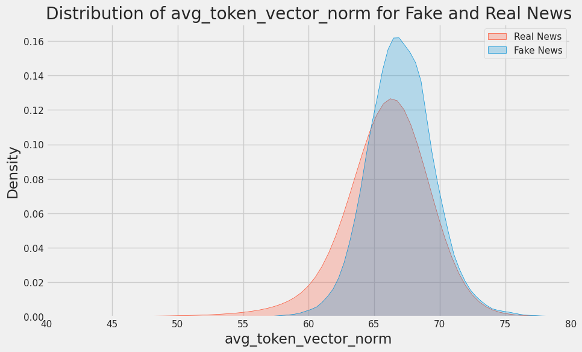

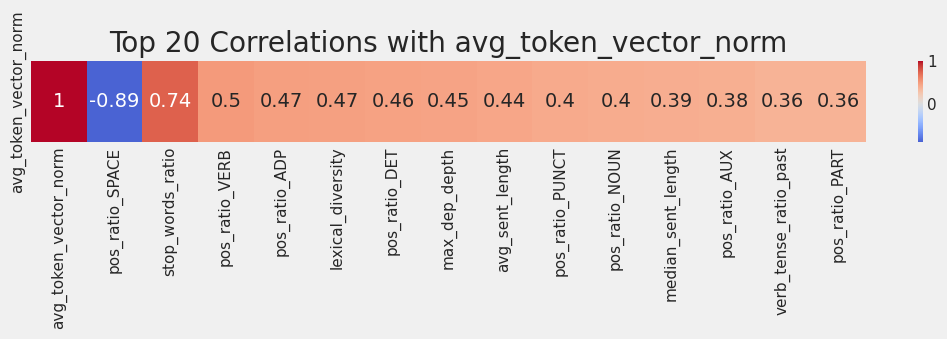

```python
da_utils.render_rel_kde_plot(ds.full_data, 'avg_token_vector_norm', x_lim=(40, 80))
da_utils.corr_strip(ds.full_data, 'avg_token_vector_norm')
```

##### 3.3.5 punctuation_density

The ratio of punctuation marks to total characters. Higher values may indicate more complex sentence structures or dialogue-heavy text

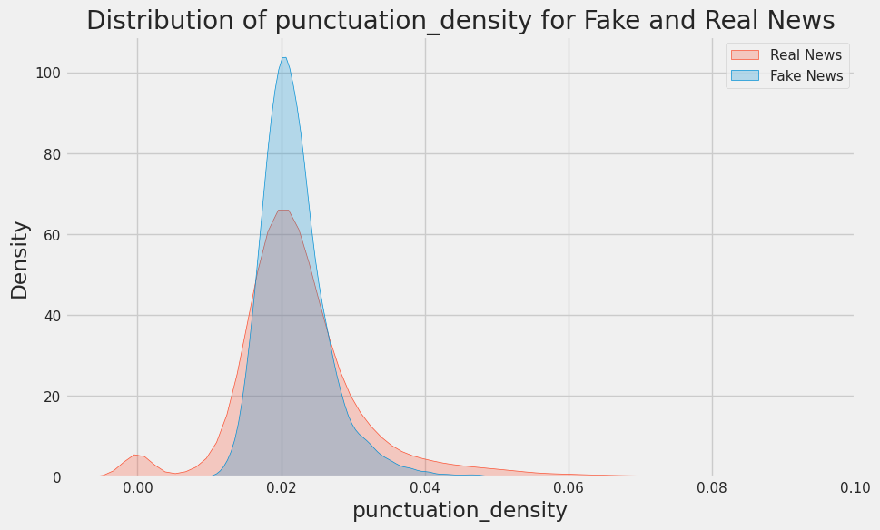

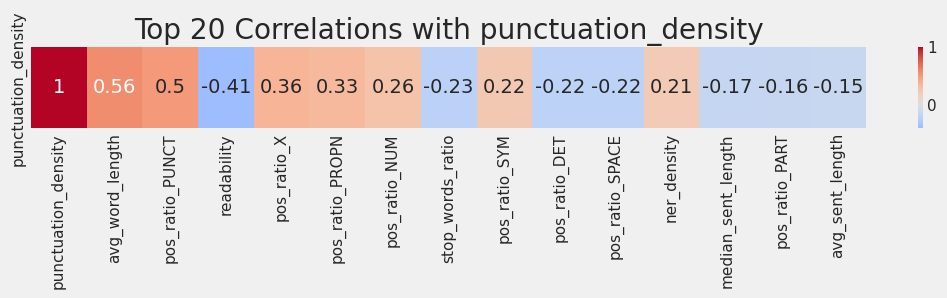

```python
da_utils.render_rel_kde_plot(ds.full_data, 'punctuation_density', x_lim=(-0.01, 0.1))
da_utils.corr_strip(ds.full_data, 'punctuation_density')
```

##### 3.3.6 std_sent_length

Standard deviation of sentence lengths. Higher values suggest more variability in sentence structure, potentially indicating more complex writing.

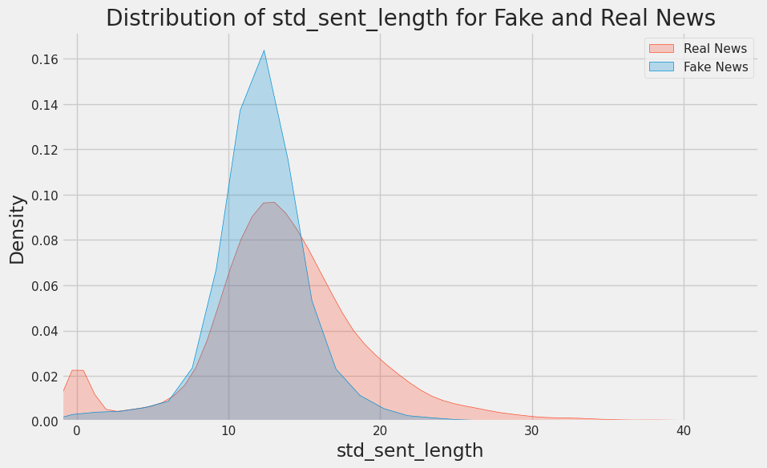

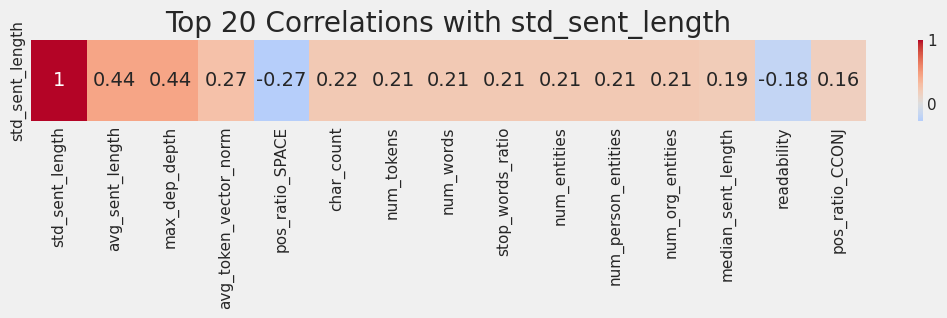

```python
da_utils.render_rel_kde_plot(ds.full_data, 'std_sent_length', x_lim=(-1, 45))
da_utils.corr_strip(ds.full_data, 'std_sent_length')
```

##### 3.3.7 pos_ratio_ADV

The proportion of adverbs in the text. A higher ratio might indicate more descriptive or nuanced language, often used to modify verbs, adjectives, or other adverbs

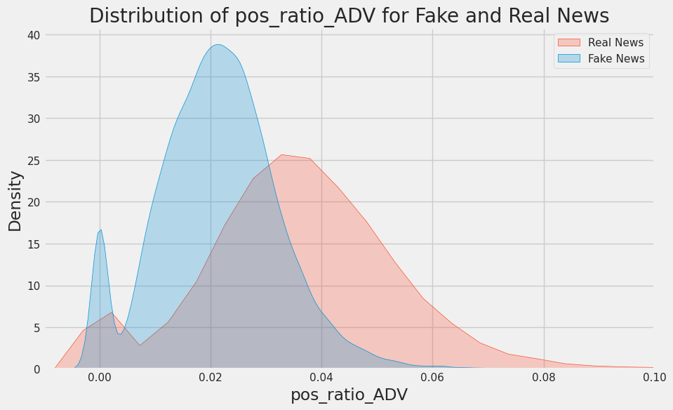

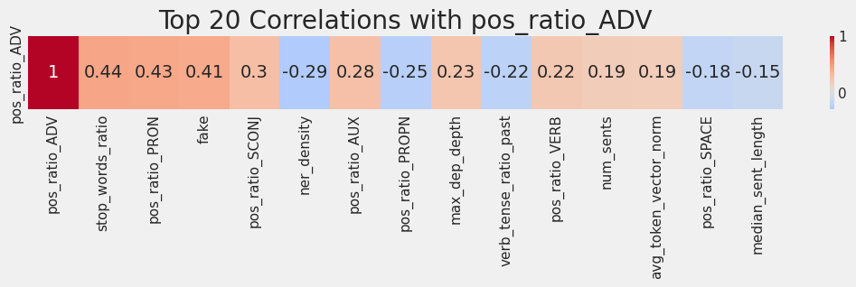

```python
da_utils.render_rel_kde_plot(ds.full_data, 'pos_ratio_ADV', x_lim=(-0.01, 0.1))
da_utils.corr_strip(ds.full_data, 'pos_ratio_ADV')
```